# Wastewater Lab - Key

## Part 3: Dive Deeper

In this section we will dive deeper into using date objects to understand time series. For that purpose, we will use influenza hospitalization rates from 2009 to 2025! You can read more about how this data is collected here: https://www.cdc.gov/fluview/overview/index.html

### 3.1: Download the Data

Start by downloading the data. The data is located here: http://daseh.org/data/FluSurveillance_2009_2025.csv

Hint: You will need to skip the first two rows of the data. Use the argument `skip=` in the `read_csv` function to do this.

```r
fludat <- read_csv("http://daseh.org/data/FluSurveillance_2009_2025.csv", skip=2)
```

### 3.2: Filter the Columns and Subsets That We Will Use

- Use the `clean_names` command from the `janitor` package to clean up the column names
- Use the commands `filter` and `select` to obtain a data set with data for the “overall” value for the age group, race, and sex categories, and keeping only the columns “YEAR…3”, “YEAR…4”, “WEEK”, “VIRUS TYPE CATEGORY”, “CUMULATIVE RATE”, and “WEEKLY RATE”
- Rename the columns `year_3` and `year_4` to more meaningful names: `flu_season` and `Year` respectively. To avoid confusion with the `week` function in `lubridate`, rename the `week` column to `num_week`
- Check the types of all columns. Transform the columns that are meant to be numeric to numeric using the function `as.numeric()`

```r
library(janitor)
fludat2 <-
  fludat |>
  clean_names() |>
  filter(age_category == "Overall",
         sex_category == "Overall",
         race_category == "Overall")

fludat2 <-
  fludat2 |>
  select(year_3,
         year_4,
         week,
         virus_type_category,
         cumulative_rate,
         weekly_rate) |>
  rename("flu_season" = year_3,
         "Year" = year_4,
         "num_week" = week) |>
  mutate(weekly_rate = as.numeric(weekly_rate))
```

### 3.3: Create a Column with the Starting Date of Each Week

We are interested in having the actual date for each entry in the `week` column. Use `lubridate`’s arithmetic to do this. Create a new column called `week_date` by adding the beginning of the year given in the column `Year` (January 1st, Year) and the number of weeks given in the column `week`.

Hint: You can do this in several steps:

```r
temp <- paste0(fludat2 |> pull(Year), "-01-01")
temp_date <- ymd(temp)
fludat2 <- fludat2 |> mutate(week_date = temp_date + weeks(num_week) - 1)
```

### 3.4: Plot a Time Series of Each Flu Season from 2015 to 2025

- Create a data frame called `df15_25` of all flu seasons between 2015 and 2025. Hint: make sure that you include *all the points* for the 2015 flu season (some of them might be in 2014!)
- Use `df15_25` to create a plot of a time series of each flu season from 2015 to 2025, coloring the lines by virus type

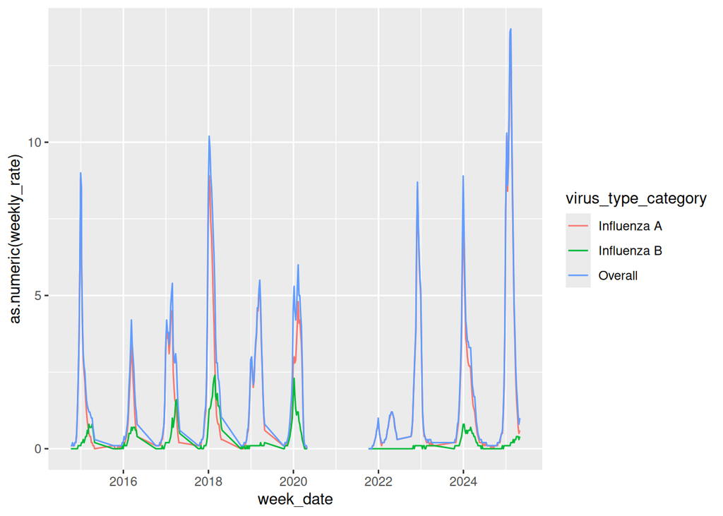

```r
df15_25 <- fludat2 |> filter(flu_season %in% c("2014-15", "2024-25") |
                           between(Year, 2015, 2025))
p <- ggplot(df15_25, aes(x=week_date, y=as.numeric(weekly_rate), color=virus_type_category)) + geom_line()
p
```

## Dealing with Missing Data

### 3.5

- What can you say about the 2020-2021 flu season? Do we have data for this season? Why? Is this data missing at random? Hint: you can look at the definition of “missing at random” in the *Data Cleaning* module
- When did the data collection stop in 2020?
- When did it restart again?
- How many weeks of data are missing?

```r
# 1. There is no data plotted for the 2020-2021 influenza season. This is because of the COVID-19 pandemic.

# 2
covid19_min <- df15_25 |> filter(flu_season == "2020-21", is.na(weekly_rate)) |> pull(week_date) |> min(na.rm = TRUE)
# Data stopped being collected on 2020-10-06.

# 3
covid19_max <- df15_25 |> filter(flu_season == "2020-21", is.na(weekly_rate)) |> pull(week_date) |> max(na.rm = TRUE)
# The last week of data not collected was 2021-04-29.

# 4
num_days_missing = covid19_max - covid19_min

num_weeks_missing = as.numeric(floor(num_days_missing/7))
num_weeks_missing
```

```
## [1] 29
```

## Comparing Influenza Seasons

We are going to focus now on comparing different influenza seasons. To do this, we will compare the overall mean weekly rate of all seasons to the seasons with the minimum and maximum peak hospitalization weekly rates.

### 3.6

```r
# Create a new data frame:
compare_df <- df15_25 |> group_by(flu_season) |> summarize("peak_flu" = max(as.numeric(weekly_rate)))

# Select the seasons with the max and min peak flu
max_season <- compare_df |> filter(peak_flu == max(peak_flu, na.rm = TRUE))
min_season <- compare_df |> filter(peak_flu == min(peak_flu, na.rm = TRUE))

# The minimum peak was in the 21-22 season with a value of 1.2 and the maximum
# The maximum peak was in the 24-25 season with a value of 13.7.
```

### 3.7

- Add a column `overall_mean_flu_rate` to the `df15_25` data set that computes the mean weekly rate for each week across seasons for each flu strain. For example, compute the mean weekly rate for week 40 for H1N1 for all seasons between 2015 and 2025

Hint: you will have to use the command `group_by` and group both by the `num_week` and the `virus_type_category` columns.

```r
df15_25 <- df15_25 |> group_by(num_week, virus_type_category) |> mutate("overall_mean_flu_rate" = mean(weekly_rate, na.rm=TRUE))
```

### 3.8

To understand the data better, we compute the difference between the 21-22 flu season (the season with the lowest peak hospitalization rate) and the overall mean hospitalization rate for each week. We then repeat this for the 24-25 flu season (the season with the highest peak hospitalization rate):

Remember to group by the `num_week` column as you want to compare each week in the data.

Keep only the 21-22 and 24-25 seasons by storing the results in new data frames called `diff_min_season` and `diff_max_season` respectively.

```r
diff_min_season <- df15_25 |> group_by(num_week) |>
  mutate("diff_rate" = weekly_rate - overall_mean_flu_rate) |>
  filter(flu_season == "2021-22")

diff_max_season <- df15_25 |> group_by(num_week) |>
  mutate("diff_rate" = weekly_rate - overall_mean_flu_rate) |>
  filter(flu_season == "2024-25")
```

### 3.9

We can now visualize the differences by doing a plot with overlaying histograms.

- Do a plot with overlaying histograms of each of the differences

```
# General idea:
diff_min_season |> select(diff_rate)
diff_max_season |> select(diff_rate)
p <- ggplot(data=XXX, aes(x=diff_rate)) + geom_histogram(fill = "blue", alpha=0.2) + geom_histogram(data=YYY, fill = "red", alpha=0.2)
# with XXX = your first data set and YYY = your second data set.
```

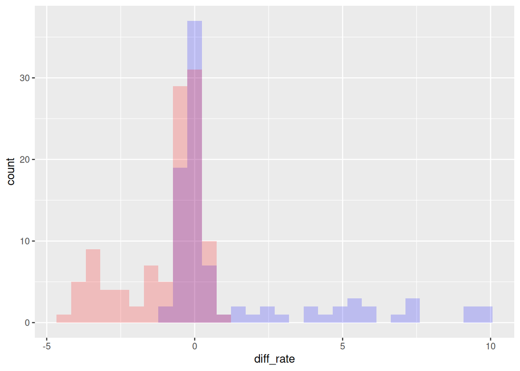

```r
p38 <- ggplot(data=diff_max_season |> select(diff_rate), aes(x=diff_rate)) + geom_histogram(fill = "blue", alpha=0.2) + geom_histogram(data=diff_min_season |> select(diff_rate), fill = "red", alpha=0.2) + theme(legend.location = "right")
p38
```

### 3.10

- Use a t-test to compare the difference between the 21-22 flu season (the one with the minimum peak hospitalization rate) and the 24-25 flu season (the one with the maximum peak hospitalization rate). Are the hospitalization rates significantly different?

Hint: create two new variables called `minSeason` and `maxSeason` by selecting the `weekly_rate` column from `df15_25` and filtering by the desired flu seasons.

```r
minSeason <- df15_25 |> filter(flu_season == "2021-22") |> pull(weekly_rate)
maxSeason <- df15_25 |> filter(flu_season == "2024-25") |> pull(weekly_rate)
mytest = t.test(minSeason, maxSeason)
mytest
```

```
##
##  Welch Two Sample t-test
##
## data:  minSeason and maxSeason
## t = -5.8008, df = 90.301, p-value = 9.628e-08
## alternative hypothesis: true difference in means is not equal to 0
## 95 percent confidence interval:
##  -3.379788 -1.655398
## sample estimates:
## mean of x mean of y
## 0.3212963 2.8388889
```

```r
# Yes, they are significantly different.
```

## Other Resources

This is a simple analysis using a t-test. For more sophisticated analysis, you can take a look at the `tseries` package for analyzing time series (https://cran.r-project.org/web/packages/tseries/index.html) or the `fable` package for forecasting models (https://fable.tidyverts.org/).